# Projet 1 – Classification bayésienne des émotions

Benadiba Keren & Zerroug Méliana

# I- Introduction

Ce projet s’inscrit dans le cadre du module **AP-4209 – Statistique bayésienne** et a pour objectif principal la mise en œuvre d’un **classificateur bayésien naïf** destiné à la prédiction des émotions à partir de textes en langage naturel.

Le jeu de données utilisé provient de la plateforme Kaggle et se compose de phrases correspondant à différentes catégories émotionnelles comme la colère ou la peur. Avant de traiter ces données, il est nécessaire d’effectuer un ensemble d’étapes de prétraitement afin de réduire le bruit et d’extraire les informations pertinentes. Ces étapes incluent notamment le nettoyage du texte, la tokenization, le stemming ou la lemmatization, ainsi que la vectorisation des données.

L’étude a pour but de mettre en évidence les forces et les limites de l’approche bayésienne dans notre contexte: la classification d’émotions.

# II- Méthodologie

Afin de préparer les données textuelles pour la modélisation, plusieurs étapes de prétraitement doivent être appliquées. Ces étapes visent à réduire le bruit du texte tout en conservant les informations les plus importantes. Le prétraitement est composé de plusieurs étapes. On commence par normaliser les données en mettant tout le texte en minuscule. Ensuite, nous supprimons les données inutiles telles que la ponctuation, les chiffres et les mots vides. Nous finirons par appliquer la tokenization et le stemming. Ces transformations permettent d’améliorer la qualité de la représentation vectorielle utilisée par le classificateur bayésien.

**Interprétation**: L’analyse de la distribution des classes permet d’identifier un possible déséquilibre entre les classes d’émotions, ce qui pourrait influencer les performances du modèle de manière négative.

Après le prétraitement, les documents textuels sont transformés en une représentation numérique à l’aide de la méthode TF-IDF. Cette méthode permet d’observer l’importance des mots en fonction de leur fréquence dans un document et de leur rareté dans l’ensemble du corpus. Pour améliorer la capacité du modèle à capturer le contexte émotionnel, nous utilisons des **bi-grammes** en plus des mots individuels. Un bi-gramme est une séquence de deux mots consécutifs (par exemple “not happy”, “very sad”). Cette approche permet au modèle de mieux comprendre les nuances de sentiment que des mots isolés ne pourraient pas capturer. Les données sont divisées en un ensemble d’apprentissage et un ensemble de test dans le but d’évaluer les performances du modèle sur des données non vues lors de l’entraînement.

Le modèle que nous allons utiliser est un **classificateur bayésien naïf**.

- **Installation des packages nécessaires :**

```r
if(!require("dplyr")) install.packages("dplyr")
if(!require("kableExtra")) install.packages("kableExtra")
if(!require("tm")) install.packages("tm")
if(!require("MASS")) install.packages("MASS")
if(!require("e1071")) install.packages("e1071")
if(!require("SnowballC")) install.packages("SnowballC")
```

- **Chargement des packages nécessaires :**

```r
library(e1071)
library(caret)
library(tm) #texte brut en texte numérique
library(SnowballC) #stemming
```

## Chargement des données

```r
data <- read.csv("Emotion_classify_Data.csv", stringsAsFactors = FALSE)
data <- data[!is.na(data$Comment) & !is.na(data$Emotion), ]
data$Comment <- trimws(data$Comment)
kable(head(data,100), caption = "Extrait du jeu de données") %>%
  kable_styling(bootstrap_options = c("striped", "hover", "condensed"), full_width = F, position = "center") %>%
  scroll_box(height = "300px", width = "100%")
```

Extrait du jeu de données

| Comment | Emotion |
| --- | --- |
| i seriously hate one subject to death but now i feel reluctant to drop it | fear |
| im so full of life i feel appalled | anger |
| i sit here to write i start to dig out my feelings and i think that i am afraid to accept the possibility that he might not make it | fear |
| ive been really angry with r and i feel like an idiot for trusting him in the first place | joy |
| i feel suspicious if there is no one outside like the rapture has happened or something | fear |
| i feel jealous becasue i wanted that kind of love the true connection between two souls and i wanted that | anger |
| when a friend of mine keeps telling me morbid things that happened to his dog | anger |
| i finally fell asleep feeling angry useless and still full of anxiety | anger |
| i feel a bit annoyed and antsy in a good way | anger |
| i feel like i ve regained another vital part of my life which is living | joy |
| i feel a bit like franz liebkind in the producers not many people know it but the fuhrer was a terrific dancer | joy |
| i was feeling at the start didnt want to move much at all was really glad to experience this glimpse into the sort of vibrant energy i will gain through out the year | joy |
| i was bitten by a dog | fear |
| i do not always find myself feeling thankful but over the years i ve gathered a few tricks that allow me to feel grateful in the face of moments when the last thing i want to do is say thanks | joy |
| i just try not to talk to anyone when i feel irritable like that | anger |
| i feel like they hated me since then | anger |
| i dont know who wrote the following little note but this is how i feel today if u r offended by the following posting then you obviously have not lived long enough to be compromised on how you act or … | anger |
| i feel offended i choose to tell you guys how i feel because i treated you guys as friends and would want to put a stop to all these nonsense | anger |
| i remember feeling as if i didn t belong and that i wasn t smart enough cool enough or even young enough | joy |
| i feel like i have to redeem myself even though i think they realized why i was distraught and were ok with it | fear |
| i hope that the next quote will be able to let my special someone knows what im feeling insecure about and understand that no matter how much i trust | fear |
| i feel much better and without the help of ice | joy |
| i am sitting here typing this and wondering where i belong feeling distracted feeling comfortable feeling misunderstood and hurt | anger |
| i still feel its a little shaky at times and can move into the slightly odd jades hair in particular seems prone to this but generally it works well with spencers writing | fear |
| i stropped about for a bit feeling grumpy because i was missing out | anger |
| i have a feeling i shall go mad | anger |
| i am happpy when i get good results in the field of academics or athletics | joy |
| i got the feeling brig is sincere and has a very strong desire to help others become successful both financially and also through building strengthening relationships through christianity | joy |
| im feeling deeply overwhelmed by these ordinary tasks | fear |
| i feel so grouchy and irritable when im sick | anger |

[output cut: 70 more lines]

```r
str(data)
```

```
## 'data.frame':    5937 obs. of  2 variables:
##  $ Comment: chr  "i seriously hate one subject to death but now i feel reluctant to drop it" "im so full of life i feel appalled" "i sit here to write i start to dig out my feelings and i think that i am afraid to accept the possibility that "| __truncated__ "ive been really angry with r and i fe…
##  $ Emotion: chr  "fear" "anger" "fear" "joy" ...
```

## Analyse des données

```r
table(data$Emotion)
```

```
##
## anger  fear   joy
##  2000  1937  2000
```

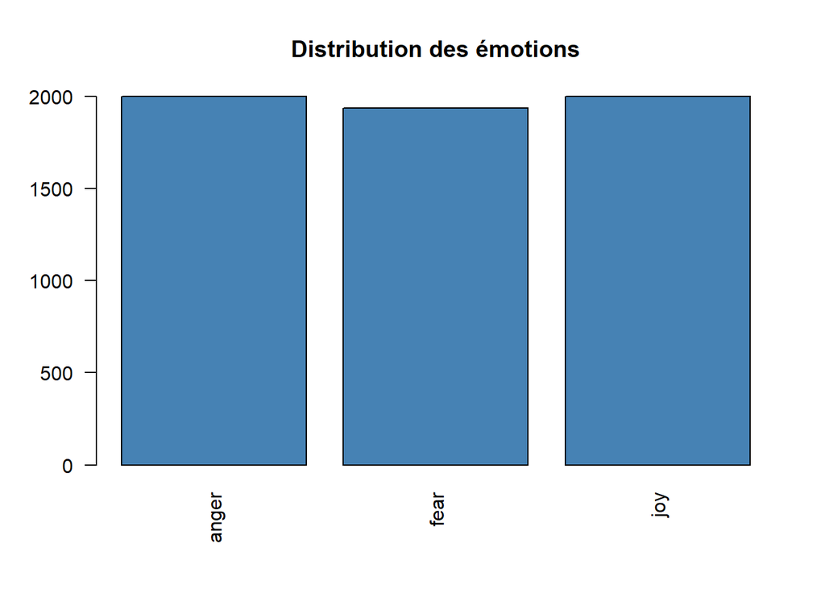

```r
barplot(table(data$Emotion),
main = "Distribution des émotions",
col = "steelblue",
las = 2)
```

## Longueur de texte

```r
names(data)
```

```
## [1] "Comment" "Emotion"
```

```r
data$text_length <- nchar(as.character(data$Comment))
summary(data$text_length)
```

```
##    Min. 1st Qu.  Median    Mean 3rd Qu.    Max.
##    9.00   54.00   86.00   97.43  130.00  298.00
```

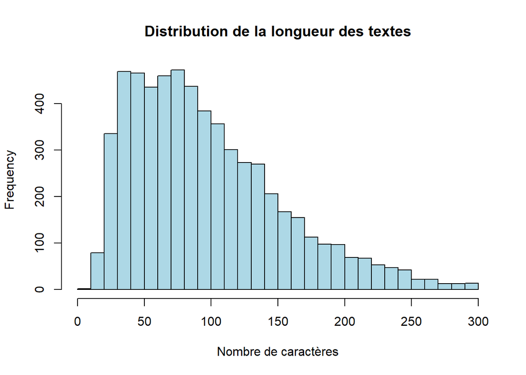

```r
hist(data$text_length,
breaks = 30,
col = "lightblue",
main = "Distribution de la longueur des textes",
xlab = "Nombre de caractères")
```

```r
# Création du corpus
corpus <- VCorpus(VectorSource(data$Comment))

# Prétraitement
corpus <- tm_map(corpus, content_transformer(tolower))
corpus <- tm_map(corpus, removePunctuation)
corpus <- tm_map(corpus, removeNumbers)
corpus <- tm_map(corpus, stripWhitespace)

stop_words <- stopwords("en")
negations <- c("not", "no", "never", "n't")
stop_words_clean <- setdiff(stop_words, negations)

corpus <- tm_map(corpus, removeWords, stop_words_clean)
corpus <- tm_map(corpus, stemDocument, language = "en")

corpus
```

```
## <<VCorpus>>
## Metadata:  corpus specific: 0, document level (indexed): 0
## Content:  documents: 5937
```

```r
# Création d'un tokenizer pour capturer les mots seuls ET les bi-grammes (sans RWeka)
BigramTokenizer <- function(x) {
  words_list <- unlist(strsplit(as.character(x), " +"))
  # Unigrammes (mots seuls)
  unigrams <- words_list
  # Bigrammes (paires de mots consécutifs)
  bigrams <- if(length(words_list) > 1) {
    sapply(1:(length(words_list)-1), function(i) paste(words_list[i], words_list[i+1]))
  } else character(0)
  # Combinaison des deux
  c(unigrams, bigrams)
}

dtm <- DocumentTermMatrix(
  corpus,
  control = list(
    tokenize = BigramTokenizer,
    weighting = weightTfIdf,
    bounds = list(global = c(5, Inf)),
    wordLengths = c(2, Inf)
  )
)
dtm <- removeSparseTerms(dtm, 0.99)

dtm
```

```
## <<DocumentTermMatrix (documents: 5937, terms: 169)>>
## Non-/sparse entries: 28514/974839
## Sparsity           : 97%
## Maximal term length: 11
## Weighting          : term frequency - inverse document frequency (normalized) (tf-idf)
```

```r
set.seed(123)

train_index <- createDataPartition(data$Emotion, p = 0.8, list = FALSE)

dtm_train <- dtm[train_index, ]
dtm_test  <- dtm[-train_index, ]

label_train <- data$Emotion[train_index]
label_test  <- data$Emotion[-train_index]
```

```r
model_nb <- naiveBayes(
  as.matrix(dtm_train),
  as.factor(label_train),
  laplace = 1
)

predictions <- predict(
  model_nb,
  as.matrix(dtm_test)
)
```

# Résultats

```r
conf_matrix <- confusionMatrix(
  as.factor(predictions),
  as.factor(label_test),
  mode = "everything"
)

conf_matrix
```

```
## Confusion Matrix and Statistics
##
##           Reference
## Prediction anger fear joy
##      anger   131   94  34
##      fear     18   58  12
##      joy     251  235 354
##
## Overall Statistics
##
##                Accuracy : 0.4575
##                  95% CI : (0.4288, 0.4863)
##     No Information Rate : 0.337
##     P-Value [Acc > NIR] : < 2.2e-16
##
##                   Kappa : 0.1827
##
##  Mcnemar's Test P-Value : < 2.2e-16
##
## Statistics by Class:
##
##                      Class: anger Class: fear Class: joy
## Sensitivity                0.3275     0.14987     0.8850
## Specificity                0.8374     0.96250     0.3825
## Pos Pred Value             0.5058     0.65909     0.4214
## Neg Pred Value             0.7101     0.70064     0.8674
## Precision                  0.5058     0.65909     0.4214
## Recall                     0.3275     0.14987     0.8850
## F1                         0.3976     0.24421     0.5710
## Prevalence                 0.3370     0.32603     0.3370
## Detection Rate             0.1104     0.04886     0.2982
## Detection Prevalence       0.2182     0.07414     0.7077
## Balanced Accuracy          0.5824     0.55619     0.6337
```

```r
#Indicateurs de performance
conf_matrix$overall[c("Accuracy", "Kappa")]
```

```
##  Accuracy     Kappa
## 0.4574558 0.1827035
```

```r
conf_matrix$byClass[, c("F1", "Sensitivity", "Specificity", "Balanced Accuracy")]
```

```
##                     F1 Sensitivity Specificity Balanced Accuracy
## Class: anger 0.3975721   0.3275000   0.8373571         0.5824285
## Class: fear  0.2442105   0.1498708   0.9625000         0.5561854
## Class: joy   0.5709677   0.8850000   0.3824651         0.6337325
```

# Validation croisée

Afin de vérifier plus concrètement l’efficacité de notre modèle nous allons appliquer une validation croisée

```r
dtm_kfold_mat <- as.matrix(removeSparseTerms(dtm, 0.995))
labels_kfold <- as.factor(data$Emotion)

train_control <- trainControl(method = "cv", number = 10)

set.seed(123)
model_kfold <- train(
  x = dtm_kfold_mat,
  y = labels_kfold,
  method = "naive_bayes",
  trControl = train_control,
  tuneGrid = expand.grid(laplace = 1, usekernel = FALSE, adjust = 1)
)

print(model_kfold)
```

```
## Naive Bayes
##
## 5937 samples
##  169 predictor
##    3 classes: 'anger', 'fear', 'joy'
##
## No pre-processing
## Resampling: Cross-Validated (10 fold)
## Summary of sample sizes: 5343, 5343, 5343, 5344, 5343, 5343, ...
## Resampling results:
##
##   Accuracy   Kappa
##   0.4520781  0.1748808
##
## Tuning parameter 'laplace' was held constant at a value of 1
## Tuning
##  parameter 'usekernel' was held constant at a value of FALSE
## Tuning
##  parameter 'adjust' was held constant at a value of 1
```

# III- Résultats

**Interprétation**:

La matrice de confusion nous permet d’analyser les performances du classificateur bayésien naïf.

L’émotion **anger** obtient une sensibilité de 0.33, cela signifie qu’environ seulement un tiers des messages de colère est correctement identifié. Cependant la spécificité est de 0.84 ce qui indique que le modèle est trop prudent et fait très peu de faux positifs. La balanced accuracy est de 0.58 cela montre une performance plutôt moyenne.

L’émotion **fear** est beaucoup plus compliqué à détecter pour notre modèle, on a une sensibilité très faible de 0.15. La grande majorité des expressions de peurs sont classées dans la joie. Cependant, elle possède la spécificité la plus élevée 0.96 cela signifie que lorsque le modèle prédit “fear” il a de fortes chances d’avoir raison.

La validation croisée (avec 10 plis) nous donne une précision d’environ 45.21%, ce résultat reste très proche du résultat que nous avions trouvé précédemment. Cela nous montre que les performances de notre modèle sont stables. Notre modèle permet donc de montrer la réelle capacité du classificateur Naive Bayes à pouvoir traiter ce jeu de données avec les prétraitements que nous avons choisi.

# IV- Discussion

Le classificateur bayésien naïf repose sur une hypothèse d’indépendance entre les mots qui ne permet pas de modéliser des textes avec du vocabulaire trop complexe. De plus, même si les classes sont équilibrées en nombre, le déséquilibre du au mots (certains mots peuvent être plus prédictifs pour une classe que pour une autre) impacte les résultats.

Ces observations montrent que des méthodes simples peuvent fournir des résultats corrects et facilement interprétables, tout en révélant rapidement leurs limites lorsque les données deviennent plus complexes, comme c’est le cas pour la classification d’émotions à partir de textes.

# V- Conclusion et perspectives